# What affect your APR when borrowing money

## Investigation overview

The annual percentage rate (APR) is used to evaluate the true cost of borrowing money. There are numbers of factors that influence a loan's APR such as :credit score and history, debt-to income ratio, annual income, the term of the loan ....etc.

## Dataset Overview

The dataset we will be analyzing is from Prosper.com, a website where individuals can either invest in personal loans or request to borrow money. The dataset contains 113,937 loans with 81 variables on each loan, including loan amount, borrower income, borrower APR and interest rate .....etc. A lot of data points were removed from the analysis due to inconsistencies or missing information. In our investigation, we will be mainly focus on these following variables: BorrowerAPR, ProsperScore, and ProperRatingAlpha.

## Distribution of the borrower APR

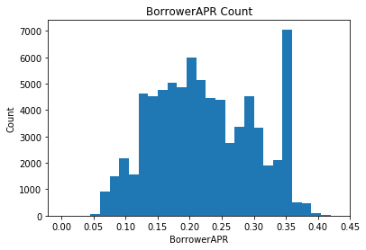

```python
#investigating further on a smaller bin size
bins = np.arange(0, df_loan['BorrowerAPR'].max(), 0.015)
plt.hist(data = df_loan, x = 'BorrowerAPR', bins = bins)
plt.xticks(np.arange(0, 0.50, 0.05))
plt.title('BorrowerAPR Count')
plt.xlabel('BorrowerAPR')
plt.ylabel('Count');
```

## Distribution of Prosper Score

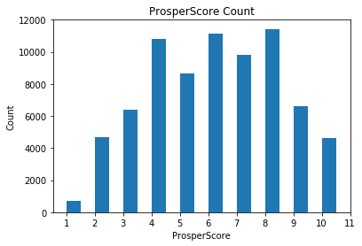

```python
# Plot ProsperScore with a smallest bin size

bins = np.arange(1, df_loan['ProsperScore'].max(), 0.5)
plt.hist(data = df_loan, x = 'ProsperScore', bins = bins)
plt.xticks(np.arange(1, 12, 1))
plt.title('ProsperScore Count')
plt.xlabel('ProsperScore')
plt.ylabel('Count');
```

## Distribution of Prosper Rating Alpha

The prosper rating alpha in the dataset varie from HR to AA. It distribution looks symetric with a peak on C.

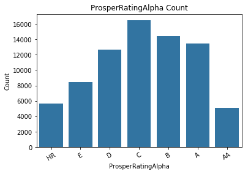

```python
# let's plot first ProsperRatingAlpha

default_color = sb.color_palette()[0]
sb.countplot(data = df_loan, x = 'ProsperRatingAlpha', color = default_color)
plt.xticks(rotation=30)
plt.title('ProsperRatingAlpha Count')
plt.xlabel('ProsperRatingAlpha')
plt.ylabel('Count');
```

## Borrower APR vs Prosper Score

The scatter and heat plot for comparing borrower APR and prosper score show the negative correlation between both. When the borrower APR is higher, the prosper score is lower.

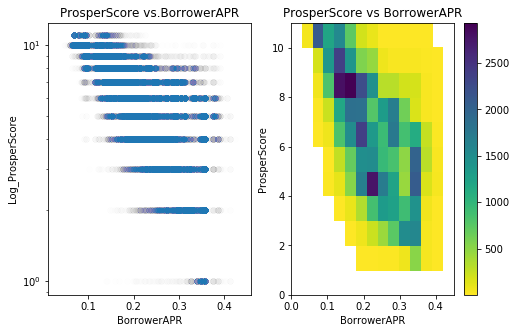

```python
# scatter and heat plot for comparing ProsperScore and BorrowerAPR.
plt.figure(figsize = [8, 5])

plt.subplot(1, 2, 1)
plt.scatter(data = df_loan, x = 'BorrowerAPR', y = 'ProsperScore', alpha =  0.005)
plt.yticks(np.arange(0, 20, 2))
plt.title('ProsperScore vs.BorrowerAPR')
plt.yscale('log')
plt.xlabel('BorrowerAPR')
plt.ylabel('Log_ProsperScore')


plt.subplot(1, 2, 2)
bins_x = np.arange(0, df_loan['BorrowerAPR'].max()+0.05, 0.03)
bins_y = np.arange(0, df_loan['ProsperScore'].max()+1, 1)
plt.hist2d(data = df_loan, x = 'BorrowerAPR', y = 'ProsperScore', bins = [bins_x, bins_y],
               cmap = 'viridis_r', cmin = 3)
plt.colorbar()
plt.title('ProsperScore vs BorrowerAPR')
plt.xlabel('BorrowerAPR')
plt.ylabel('ProsperScore');
```

## Borrower APR vs. Prosper Rating Alpha

According to the violin plot of Borrower APR by Prosper Rating Alpha , if the borrower APR is hight, the prosper rating alpha is lower.

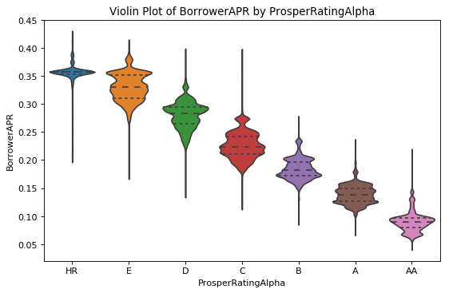

```python
# let plot the two categorical variables against BorrowerAPR
# with full data and variable transforms
plt.figure(figsize=(8,5), dpi= 80)
sb.violinplot(x='ProsperRatingAlpha', y='BorrowerAPR', data=df_loan, scale='width', inner='quartile')
plt.title('Violin Plot of BorrowerAPR by ProsperRatingAlpha', fontsize=12)
plt.show()
```

## Prosper Score vs. Prosper Rating Alpha

This violin plot of Prosper Score by Prosper Rating Alpha, shows a nice correlation between both. If the ProsperScore is good, the prosper Rating Alpha is good as well.

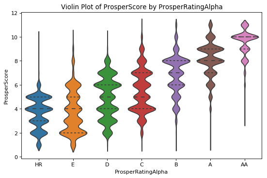

```python
# let plot the two categorical variables against ProsperScore this time
# with full data and variable transforms

plt.figure(figsize=(8,5), dpi= 80)
sb.violinplot(x='ProsperRatingAlpha', y='ProsperScore', data=df_loan, scale='width', inner='quartile')
plt.title('Violin Plot of ProsperScore by ProsperRatingAlpha', fontsize=12)
plt.show()
```

## Borrower APR by Prosper Rating Alpha and Prosper Score

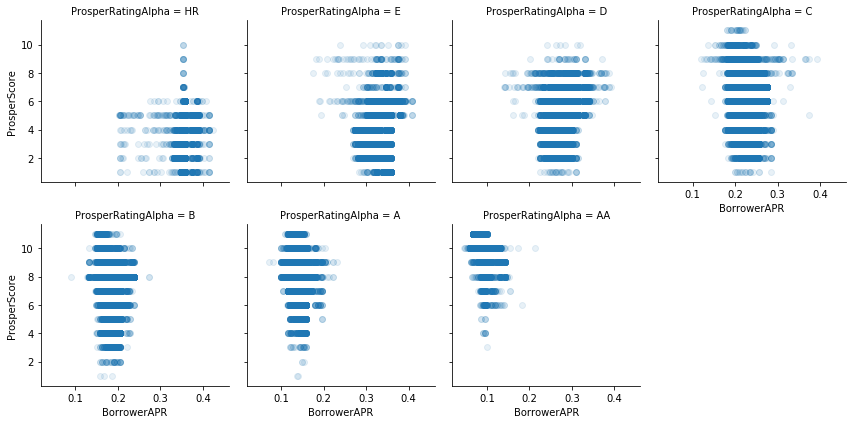

```python
# FacetGrid for ProsperRatingAlpha
g = sb.FacetGrid(data = df_loan, col = 'ProsperRatingAlpha', col_wrap = 4, height = 3)
g.map(plt.scatter, 'BorrowerAPR', 'ProsperScore', alpha = 0.1)
g.set_xlabels('BorrowerAPR')
g.set_ylabels('ProsperScore')

plt.show()
```